# Assignment01_Part2_solution

## Part 2: Deep Neural Networks (DNN)

[Total marks for this part: 30 points]

**The second part of this assignment is for you to demonstrate your basis knowledge in TF 1.x and feedforward neural networks that you have acquired from the lectures and tutorials materials.**

**In the second part of this assignment, you are going to work with the `FashionMNIST` dataset for `image recognition task`. It has the exact same format as MNIST (70,000 grayscale images of 28 × 28 pixels each, with 10 classes), but the images represent fashion items rather than handwritten digits, so each class is more diverse, and the problem turns out to be significantly more challenging than MNIST.**

#### **Question 2.1.** Load the Fashion MNIST using Keras datasets

[5 points]

We first use keras incoporated in TensorFlow 2.x for loading the training and testing sets.

```python
import tensorflow as tf
from tensorflow import keras
```

We first use keras datasets in TF 2.x to load Fashion MNIST dataset.

```python
fashion_mnist = keras.datasets.fashion_mnist
(X_train_full_img, y_train_full), (X_test_img, y_test) = fashion_mnist.load_data()
```

The shape of X_train_full_img is $(60000, 28, 28 )$ and that of X_test_img is $(10000, 28, 28)$. We next convert them to matrices of vectors and store in X_train_full and X_test.

```python
num_train = X_train_full_img.shape[0]
num_test = X_test_img.shape[0]
X_train_full =  X_train_full_img.reshape(num_train, -1)   # Convert to matrices of vectors with all the same data
X_test = X_test_img.reshape(num_test, -1)   # Convert to matrices of vectors with all the same data
print(X_train_full.shape, y_train_full.shape)
print(X_test.shape, y_test.shape)
```

```
(60000, 784) (60000,)
(10000, 784) (10000,)
```

#### **Question 2.2.** Preprocess the dataset and split into training, validation, and testing datasets

You need to write the code to address the following requirements:

- Use $10 \%$ of X_train_full for validation and the rest of X_train_full for training. This splits X_train_full and y_train_full into X_train, y_train ($90 \%$) and X_valid, y_valid ($10 \%$).
- Finally, scale the piels of X_train, X_valid, and X_test to $[0,1]$) (i.e., $X = X/255.0$).

[5 points]

```python
import math
N = X_train_full.shape[0]
i = math.floor(0.9*N)
X_train, y_train = X_train_full[0:i], y_train_full[0:i]
X_valid, y_valid = X_train_full[i:], y_train_full[i:]
X_train, X_valid, X_test = X_train/255.0, X_valid/255.0, X_test/255.0
```

You have now the separate training, validation, and testing sets for training your model.

#### **Question 2.3.** Visualize some images in the training set with labels

[5 points]

You are required to write the code to show the first $36$ images in X_train_full_img (which is an array of images) with labels as shown in the following figure. Note that the class names of Fashion MNIST are as follows

- "T-shirt/top", "Trouser", "Pullover", "Dress", "Coat", "Sandal", "Shirt", "Sneaker", "Bag", "Ankle boot"

[figure not shown]

```python
import matplotlib.pyplot as plt
%matplotlib inline
```

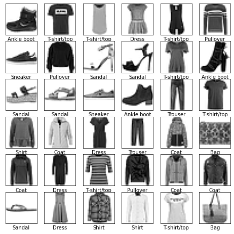

```python
# YOU ARE REQUIRED TO INSERT YOUR CODES IN THIS CELL
class_names = ["T-shirt/top", "Trouser", "Pullover", "Dress", "Coat", "Sandal", "Shirt", "Sneaker", "Bag", "Ankle boot"]

plt.figure(figsize=(8,8))
for i in range(36):
    plt.subplot(6,6,i+1)
    plt.xticks([])
    plt.yticks([])
    plt.grid(False)
    plt.imshow(X_train_full_img[i], cmap=plt.cm.binary) # show the image
    plt.xlabel(class_names[y_train_full[i]]) # find label corresponding in class_names
plt.show() # show the plot
```

#### **Question 2.4.** Write code for the dense layer

[5 points]

We now develop a feed-forward neural networks with the architecture $784 \rightarrow 20(ReLU) \rightarrow 25(ReLU) \rightarrow 10(softmax)$. We first declare the code for the hidden layer with a linear operation and activation. Since we are implementing using TF 1.x syntax, we first import the compatible version of TF 1.x in TF 2.x.

```python
import tensorflow.compat.v1 as tf
tf.disable_v2_behavior()
```

```
WARNING:tensorflow:From /Users/daniaismadi/opt/anaconda3/envs/tf2_cpu/lib/python3.7/site-packages/tensorflow_core/python/compat/v2_compat.py:88: disable_resource_variables (from tensorflow.python.ops.variable_scope) is deprecated and will be removed in a future version.
Instructions for updating:
non-resource variables are not supported in the long term
```

```python
# YOU ARE REQUIRED TO INSERT YOUR CODES IN THIS CELL [3 marks]
import numpy as np

# x is the input, num_neurons is the number of neurons in the hidden layer
# name is the name of the hidden layer, activation is the activation function specified
def dense_layer(x, num_neurons, name, activation=None):
    with tf.name_scope(name):
        num_inputs = int(x.get_shape()[1])   # Get the number of inputs
        stddev = 2 / np.sqrt(num_inputs)   # Standard deviation of the number of inputs
        init = tf.truncated_normal([num_inputs, num_neurons], stddev=stddev)
        W = tf.Variable(init, name="W")   # Initialise the weight
        b = tf.Variable(tf.truncated_normal([num_neurons], stddev=stddev), name="b")   # Initialise the bias
        # xW + b, shape = (x.get_shape()[0], num_neurons)
        z = tf.matmul(x, W) + b
    if activation == "sigmoid":
        return tf.nn.sigmoid(z)
    elif activation == "relu":
        return tf.nn.relu(z)
    else:
        return z
```

#### **Question 2.5.** Declare your network and visualize quantities of interest using TensorBoard

[5 points]

It is the time to implement your network with the architecture $784 \rightarrow 20(ReLU) \rightarrow 25(ReLU) \rightarrow 10(softmax)$. Note that we need to store and visualize the following quantities using TensorBoard:

- Gradients of trainable variables (weight matrices and biases) (Hint: use method `compute_gradients` with respect to the loss function).
- Hidden layers 1 and 2.

```python
num_hidden1 = 20
num_hidden2 = 25
num_outputs = 10
num_inputs = 784  #28 x 28
```

*Run the following cell to create necessary subfolders for this assignment. You must **not** modify these codes and **must** run it first*.

```python
# Create necessary subfolders to store immediate files for this assignment.

import os
if not os.path.exists("./models/dnn0"):
    os.makedirs("models/dnn0")
```

```python
inputs = tf.placeholder(tf.float32, shape=[None, num_inputs], name="inputs")
labels = tf.placeholder(tf.int32, shape=[None], name="labels")

with tf.name_scope("dnn"):
    hidden1 = dense_layer(inputs, num_hidden1, name="layer1", activation="relu")
    hidden2 = dense_layer(hidden1, num_hidden2, name="layer2", activation="relu")
    logits = dense_layer(hidden2, num_outputs, name="logits")

with tf.name_scope("loss"):
    # sparse_softmax_cross_entropy... because labels y_train is in categorical format (i.e., y_train=[0,1,0,1,1,2])
    xentropy = tf.nn.sparse_softmax_cross_entropy_with_logits(labels=labels, logits=logits, name='xentropy')
    loss = tf.reduce_mean(xentropy, name="loss")

with tf.name_scope("evaluation"):
    # in_top_k() with k=1 returns a 1D tensor full of boolean values
    correct =  tf.nn.in_top_k(logits, labels, 1)
    # cast boolean values to floats and compute the average
    accuracy = tf.reduce_mean(tf.cast(correct, tf.float32))

with tf.name_scope("train"):
    learning_rate = 0.001
    # Use the Adam optimizer for this optimization
    optimizer = tf.train.AdamOptimizer(learning_rate=learning_rate)
    grads = optimizer.compute_gradients(loss)
    training_op = optimizer.apply_gradients(grads)

    for var in tf.trainable_variables():
        tf.summary.histogram(var.op.name + "/values", var)

    for grad, var in grads:
        if grad is not None:
            tf.summary.histogram(var.op.name + "/gradients", grad)

# summary
accuracy_summary = tf.summary.scalar("accuracy", accuracy)
```

```python
# YOU ARE REQUIRED TO INSERT YOUR CODES IN THIS CELL [5 marks]

# merge all summary
tf.summary.histogram('hidden1/activations', hidden1)
tf.summary.histogram('hidden2/activations', hidden2)
merged = tf.summary.merge_all()

init = tf.global_variables_initializer()
saver = tf.train.Saver()  # Add ops to save and restore all the variables.

train_writer = tf.summary.FileWriter("models/dnn0/train", tf.get_default_graph())
test_writer = tf.summary.FileWriter("models/dnn0/test", tf.get_default_graph())

num_epochs = 50
batch_size = 128
```

#### **Question 2.6.** Train your network and report the resutls, and inspect the computational graph and visualize the gradients, hidden layers 1,2

[5 points]

The **first** part of this sub-question requires you to write codes in the following cell.

```python
# This is needed so my kernel does not die when training.
import os
os.environ['KMP_DUPLICATE_LIB_OK']='True'
```

```python
# YOU ARE REQUIRED TO INSERT YOUR CODES IN THIS CELL

with tf.Session() as sess:
    init.run()
    print("Epoch\tTrain accuracy\tValid accuracy")
    for epoch in range(num_epochs):
        for idx_start in range(0, X_train.shape[0], batch_size):
            idx_end = min(X_train.shape[0], idx_start+batch_size)   # min so it doesn't go above the maximum number
            X_batch, y_batch = X_train[idx_start:idx_end], y_train[idx_start:idx_end]
            sess.run(training_op, feed_dict={inputs: X_batch, labels: y_batch})

        summary_train, acc_train = sess.run([merged, accuracy], feed_dict={inputs:X_train, labels:y_train})
        summary_valid, acc_valid = sess.run([merged, accuracy], feed_dict={inputs:X_valid, labels:y_valid})

        train_writer.add_summary(summary_train, epoch)
        test_writer.add_summary(summary_valid, epoch)

        print("{}\t{}\t{}".format(epoch, acc_train, acc_valid))

    save_path = saver.save(sess, "models/dnn0.ckpt")
```

```
Epoch	Train accuracy	Valid accuracy
0	0.836555540561676	0.8309999704360962
1	0.8558148145675659	0.8476666808128357
2	0.8634999990463257	0.8513333201408386
3	0.8690370321273804	0.8560000061988831
4	0.8724074363708496	0.8618333339691162
5	0.8752962946891785	0.8638333082199097
6	0.8752962946891785	0.8650000095367432
7	0.878074049949646	0.8644999861717224
8	0.8785370588302612	0.8646666407585144
9	0.880907416343689	0.8648333549499512
10	0.8818888664245605	0.8643333315849304
11	0.8820740580558777	0.8631666898727417
12	0.8840740919113159	0.8643333315849304
13	0.8852592706680298	0.8658333420753479
14	0.8869629502296448	0.8658333420753479
15	0.8878518342971802	0.8648333549499512
16	0.8898518681526184	0.8644999861717224
17	0.8908148407936096	0.8648333549499512
18	0.8905370235443115	0.8646666407585144
19	0.8912777900695801	0.8673333525657654
20	0.8917592763900757	0.8659999966621399
21	0.8919629454612732	0.8659999966621399
22	0.8926481604576111	0.8658333420753479
23	0.8925555348396301	0.8666666746139526
24	0.892296314239502	0.8658333420753479
25	0.8931851983070374	0.8651666641235352
26	0.8934814929962158	0.8654999732971191
27	0.8940555453300476	0.8634999990463257
28	0.8946666717529297	0.8638333082199097
29	0.8942037224769592	0.8643333315849304
30	0.8957222104072571	0.8651666641235352
31	0.895370364189148	0.8650000095367432
32	0.8970184922218323	0.8646666407585144
33	0.8964999914169312	0.8656666874885559
34	0.8975740671157837	0.8658333420753479
35	0.896907389163971	0.8659999966621399
36	0.8974629640579224	0.8656666874885559
37	0.89811110496521	0.8651666641235352
38	0.8990185260772705	0.8659999966621399
39	0.8998148441314697	0.8665000200271606
40	0.9001481533050537	0.8671666383743286
41	0.9010370373725891	0.8663333058357239
42	0.9018333554267883	0.8669999837875366
43	0.8996852040290833	0.8640000224113464
44	0.9004999995231628	0.8653333187103271
45	0.9017037153244019	0.8668333292007446
46	0.9021481275558472	0.8673333525657654
47	0.9025925993919373	0.8675000071525574
48	0.9024814963340759	0.8659999966621399
49	0.9025185108184814	0.8653333187103271
```

The **second** part of this subquestion requires you use the Tensorboard, find out relevant visualizations and input them into the markdown cell below. (*Hint*: A software to capture the screen such as *Snipping Tools* in *Windows* may help).

**YOU ARE REQUIRED TO INSERT YOUR OWN GRAPHICS IN THIS MARKDOWN CELL**

- **Hidden activations**:

[output not shown]

- **Parameter gradients**:

[output not shown]

END OF PART 2